# MiFit data analysis report

User_name

2022.10.19

You have been wearing a fitness bracelet from 2019.06.13 to 2020.06.12.

Data are available for 365 (99.73%) days out of 366 total days.

Your daily steps goal is 8000 steps a day.

You have successfully achieved your daily steps goal during 212 (58.08%) days in total.

You slept for 114.72 (31.43%) days in total.

You walked 2260.42 kilometers in total.

You walked 3006.43 thousand steps in total.

You ran 278.19 kilometers.

Your stride length is 0.75 meter.

MiFit data sleep statistics

|  | Total sleep time (hours) | Deep sleep time (hours) | Shallow sleep time (hours) | Start sleep time | Stop sleep time | Deep sleep time/Total sleep time ratio |
| --- | --- | --- | --- | --- | --- | --- |
| count | 365.0 | 365.0 | 365.0 | 365.0 | 365.0 | 332.0 |
| mean | 7.54 | 1.64 | 5.9 | 4.45 | 9.91 | 0.22 |
| std | 3.0 | 0.9 | 2.47 | 6.1 | 3.61 | 0.09 |
| min | 0.0 | 0.0 | 0.0 | 0.0 | 0.0 | 0.0 |
| 25% | 6.95 | 1.1 | 5.15 | 1.27 | 9.1 | 0.16 |
| 50% | 8.08 | 1.75 | 6.4 | 2.7 | 10.42 | 0.22 |
| 75% | 9.4 | 2.23 | 7.42 | 4.3 | 11.9 | 0.28 |
| max | 15.52 | 5.3 | 13.42 | 23.98 | 20.98 | 0.51 |

MiFit data activity statistics

|  | Steps | Distance | Run distance | Calories |
| --- | --- | --- | --- | --- |
| count | 365.0 | 365.0 | 365.0 | 365.0 |
| mean | 8236.79 | 6192.94 | 762.15 | 216.38 |
| std | 5603.27 | 4238.8 | 859.7 | 146.57 |
| min | 0.0 | 0.0 | 0.0 | 0.0 |
| 25% | 3504.0 | 2523.0 | 145.0 | 91.0 |
| 50% | 8656.0 | 6574.0 | 509.0 | 235.0 |
| 75% | 10871.0 | 8254.0 | 946.0 | 290.0 |
| max | 28835.0 | 21664.0 | 6117.0 | 786.0 |

MiFit data activity stage statistics

|  | Distance, (meters) | Calories | Steps | Stage duration, (minutes) | Steps/min | m/min | m/s | km/h |
| --- | --- | --- | --- | --- | --- | --- | --- | --- |
| count | 2939.0 | 2939.0 | 2939.0 | 2939.0 | 2939.0 | 2939.0 | 2939.0 | 2939.0 |
| mean | 646.29 | 22.0 | 850.94 | 13.35 | 69.83 | 52.78 | 0.88 | 3.17 |
| std | 730.29 | 26.45 | 932.47 | 11.49 | 42.9 | 34.96 | 0.58 | 2.1 |
| min | 28.0 | 1.0 | 42.0 | 3.0 | 1.97 | 1.3 | 0.02 | 0.08 |
| 25% | 174.0 | 5.0 | 258.5 | 5.0 | 33.56 | 23.24 | 0.39 | 1.39 |
| 50% | 436.0 | 14.0 | 581.0 | 10.0 | 62.0 | 44.13 | 0.74 | 2.65 |
| 75% | 798.0 | 27.0 | 1046.0 | 17.0 | 109.27 | 85.13 | 1.42 | 5.11 |
| max | 10557.0 | 355.0 | 13114.0 | 122.0 | 181.0 | 157.0 | 2.62 | 9.42 |

MiFit data top 10 step days

| Date | Day | Steps | Distance | Run distance |
| --- | --- | --- | --- | --- |
| 2019-12-15 | Sunday | 28835 | 21664 | 6117 |
| 2019-12-14 | Saturday | 27248 | 20471 | 4974 |
| 2019-07-14 | Sunday | 26876 | 18861 | 889 |
| 2020-01-19 | Sunday | 26863 | 20093 | 4589 |
| 2020-01-08 | Wednesday | 25668 | 19362 | 569 |
| 2020-02-15 | Saturday | 25300 | 19397 | 1849 |
| 2020-01-24 | Friday | 23896 | 18149 | 2013 |
| 2020-02-21 | Friday | 22085 | 17328 | 1768 |
| 2019-08-03 | Saturday | 20676 | 15667 | 926 |
| 2019-06-30 | Sunday | 20435 | 14924 | 1173 |

Here you can find your plots

Here you can find your sleep common plots

sleep_hours_pairplot.png

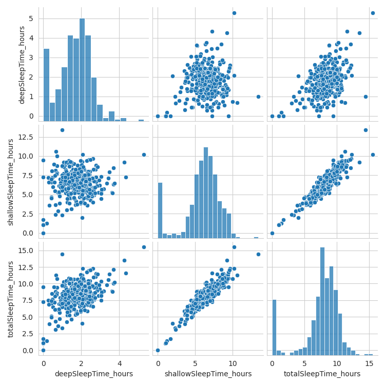

sleep_hours_boxplot.png

[figure not shown]

sleep_hours_correlations_plot.png

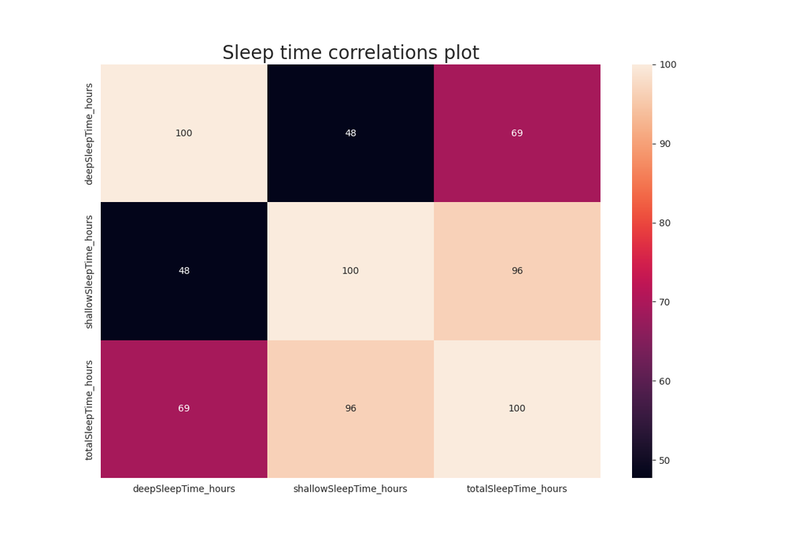

sleep_correlations_plot.png

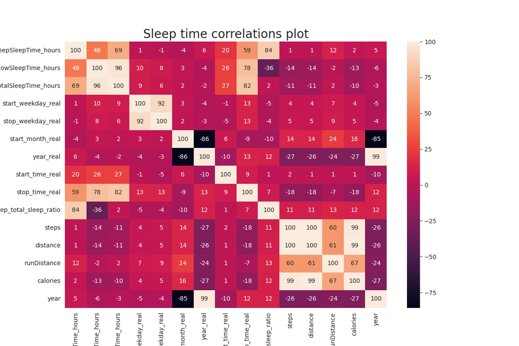

sleep_hours_scatterplot.png

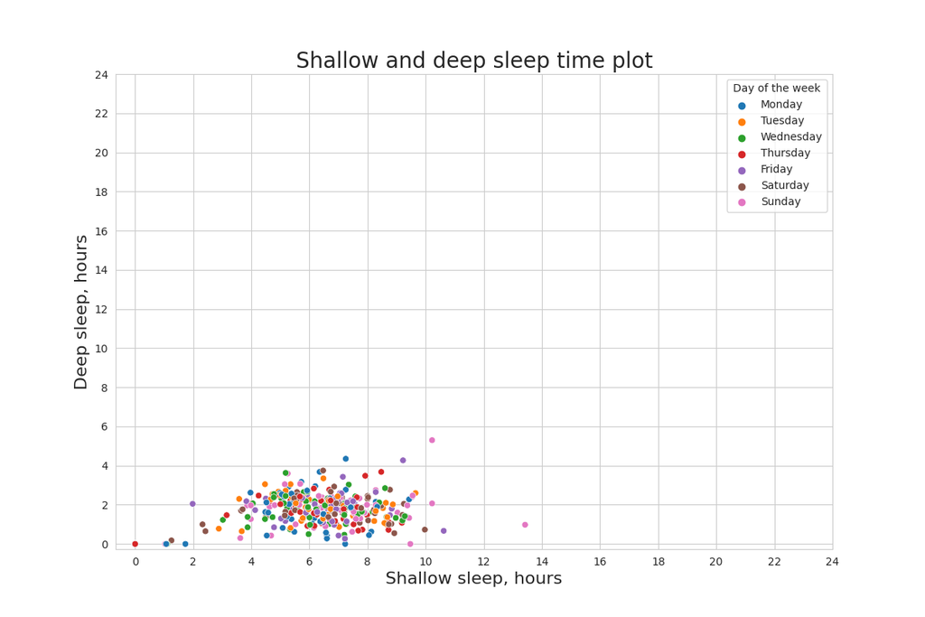

Here you can find your sleep hours boxplots

sleep_hours_per_start_weekday_boxplot.png

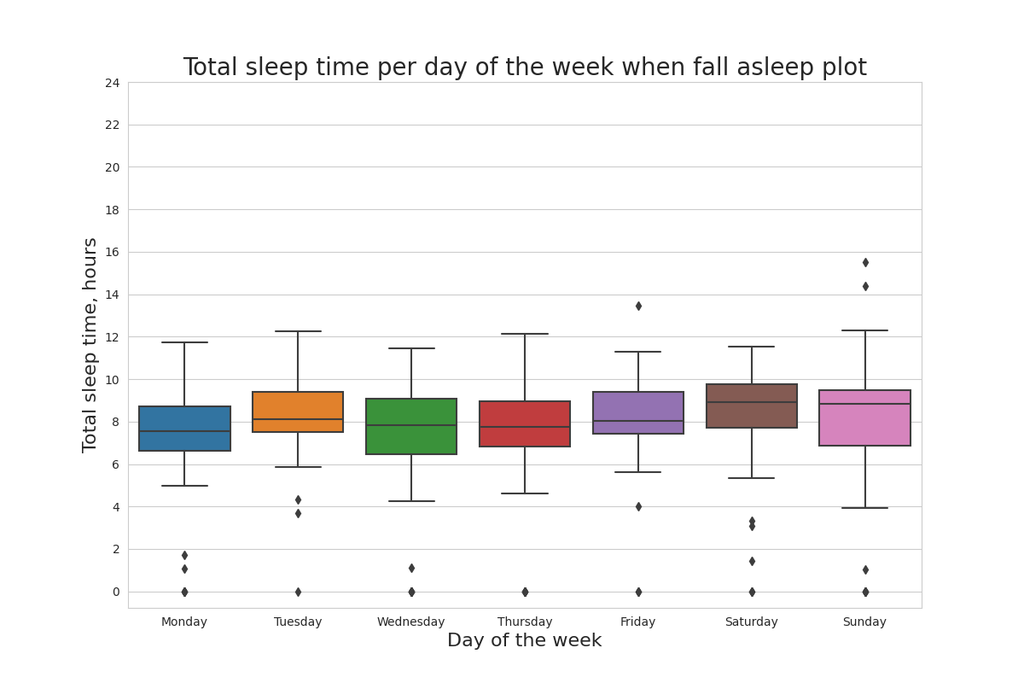

sleep_hours_per_stop_weekday_boxplot.png

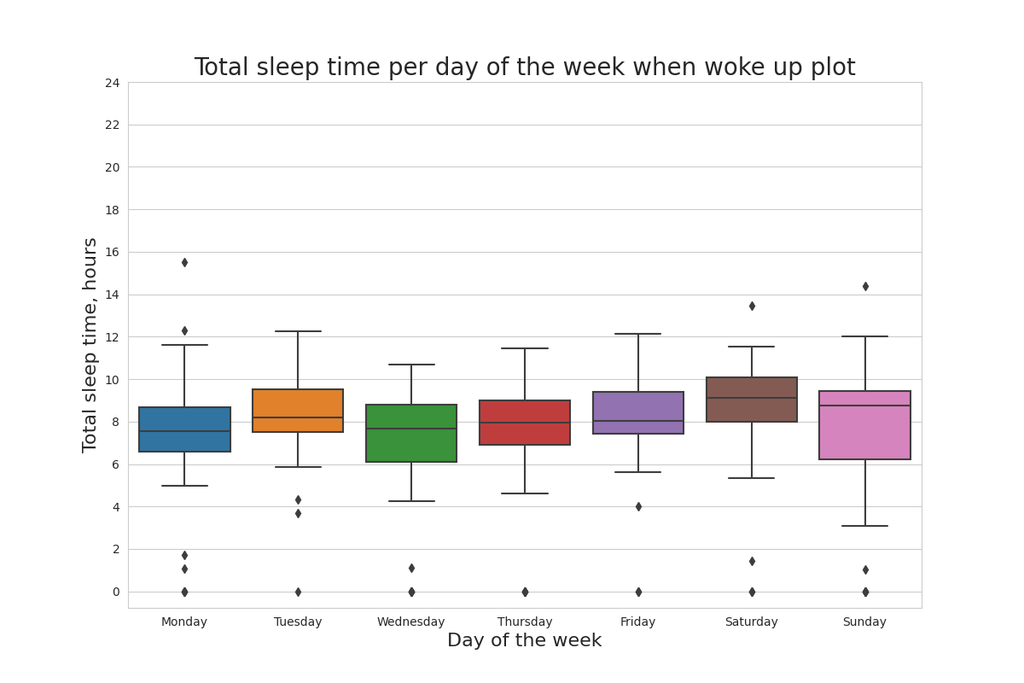

sleep_hours_per_start_month_boxplot.png

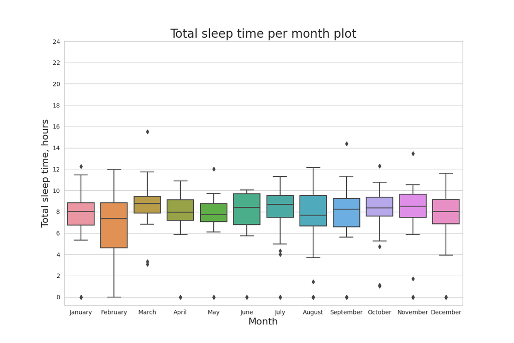

sleep_stop_time_per_year_boxplot.png

[figure not shown]

Here you can find your sleep deep hours boxplots

sleep_deep_hours_per_weekday_boxplot.png

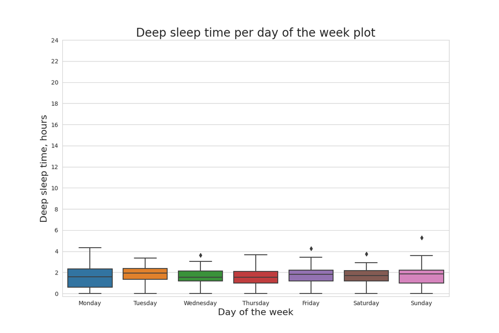

sleep_deep_hours_per_month_boxplot.png

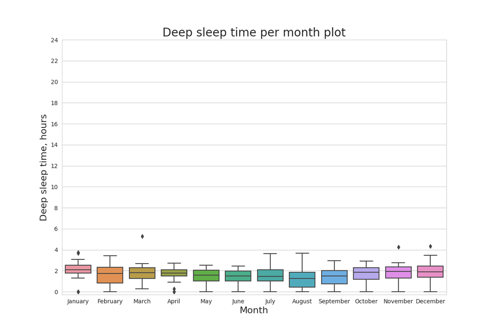

sleep_deep_hours_per_year_boxplot.png

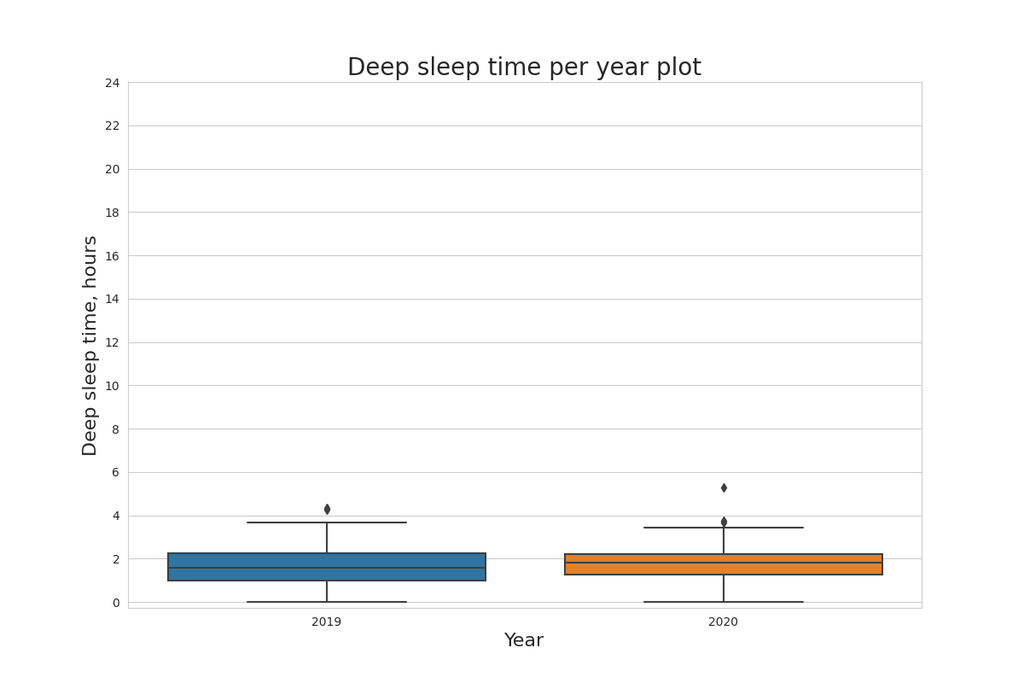

Here you can find your sleep shallow hours boxplots

sleep_shallow_hours_per_weekday_boxplot.png

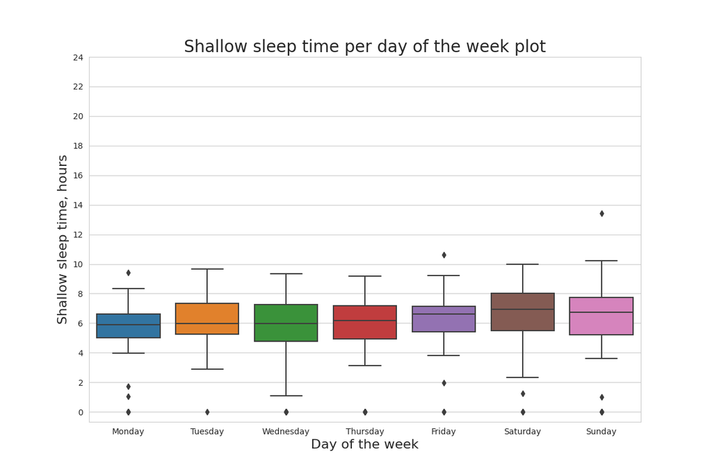

sleep_shallow_hours_per_month_boxplot.png

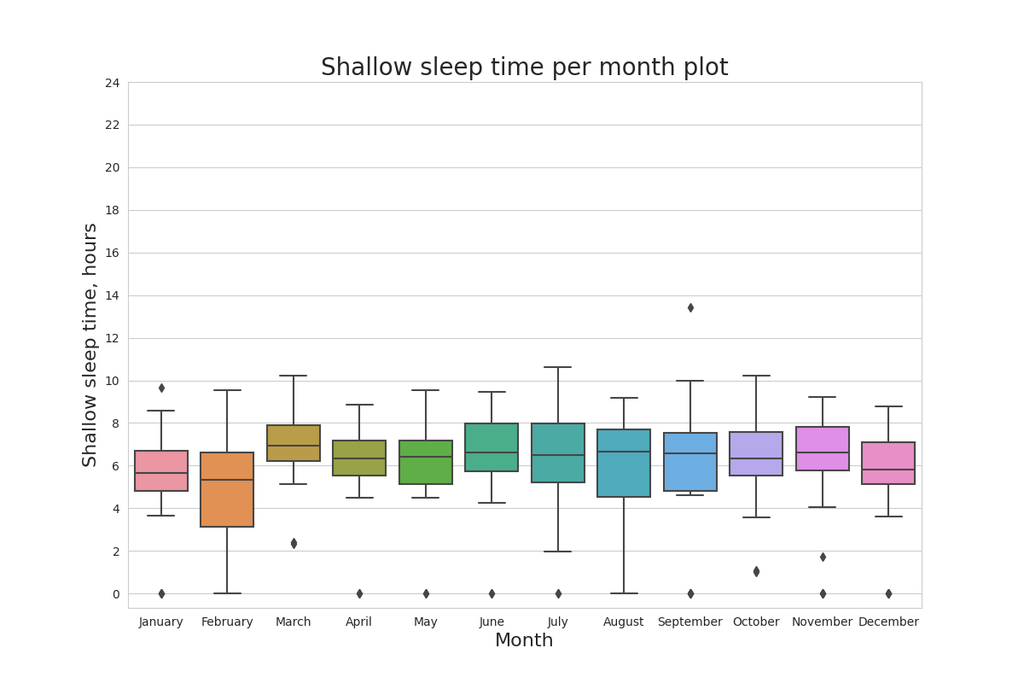

sleep_shallow_hours_per_year_boxplot.png

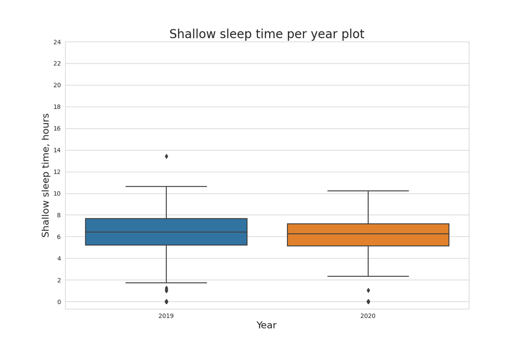

sleep_start_and_stop_time_scatterplot.png

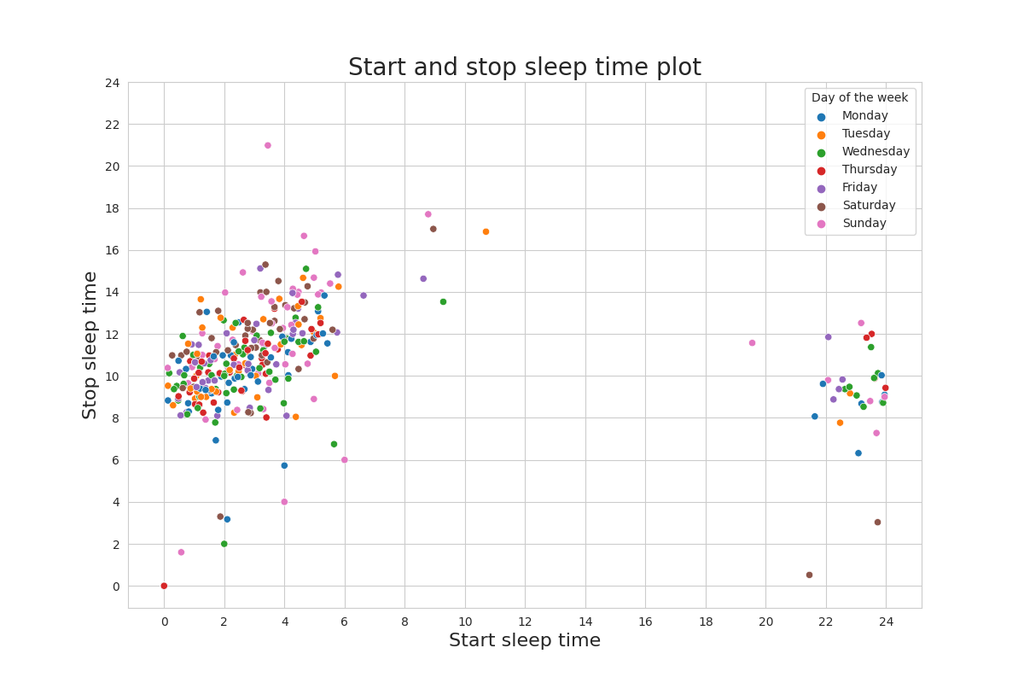

Here you can find your sleep start time boxplots

sleep_start_time_per_weekday_boxplot.png

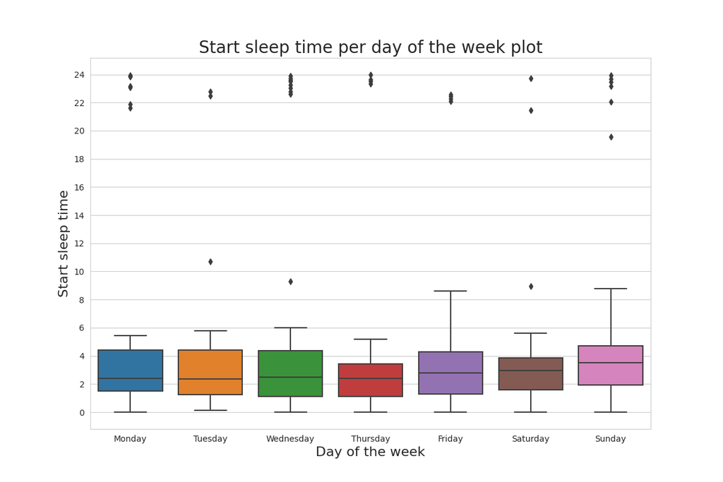

sleep_start_time_per_month_boxplot.png

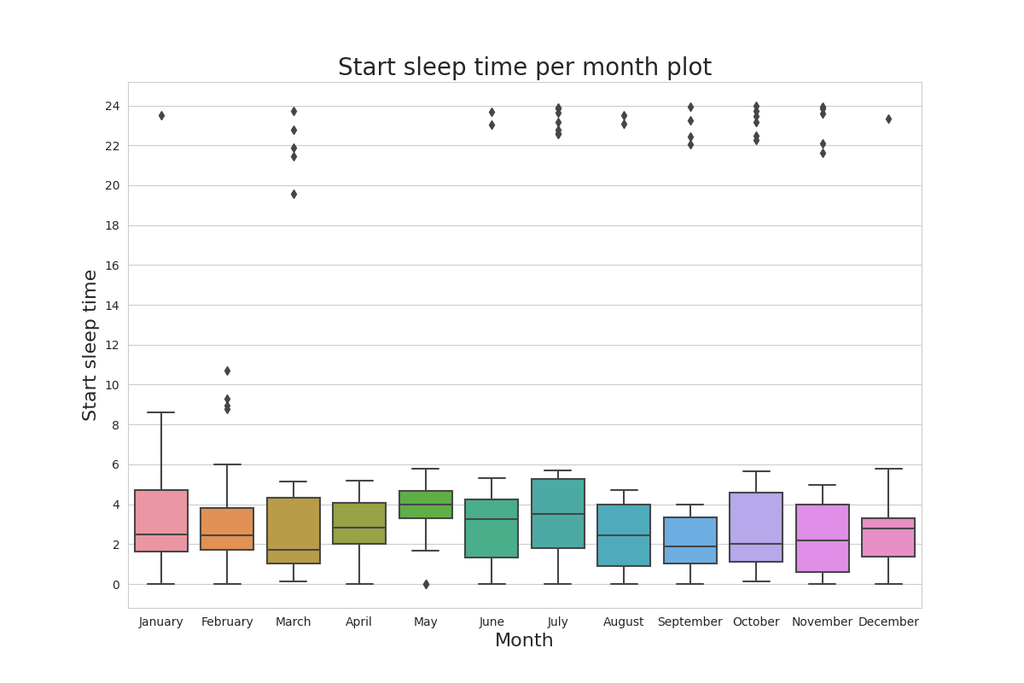

sleep_start_time_per_year_boxplot.png

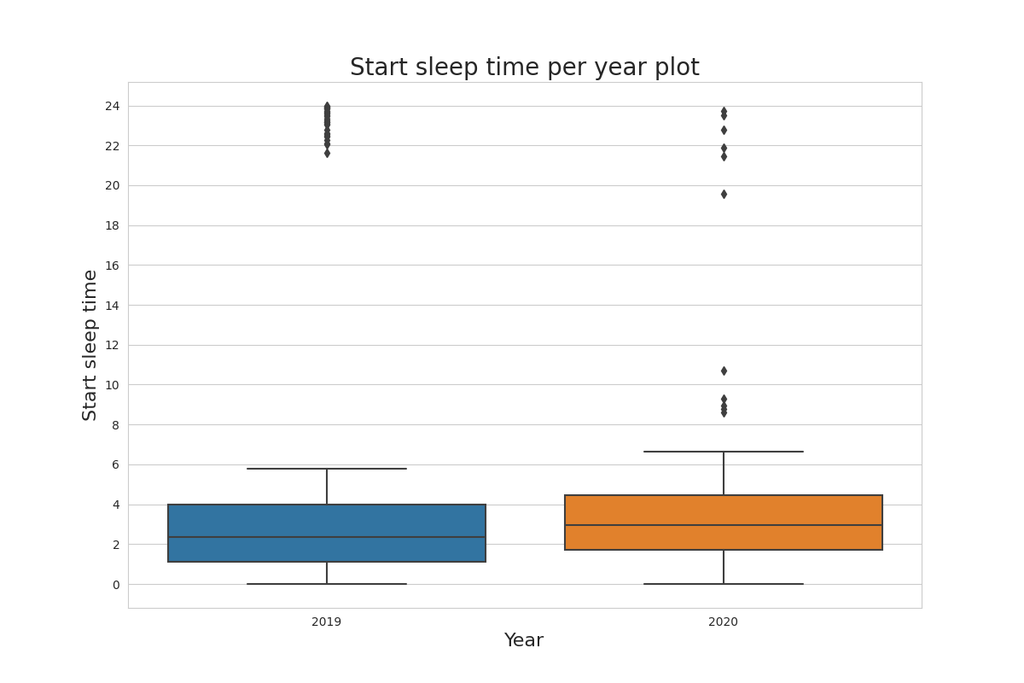

Here you can find your sleep stop time boxplots

sleep_stop_time_per_weekday_boxplot.png

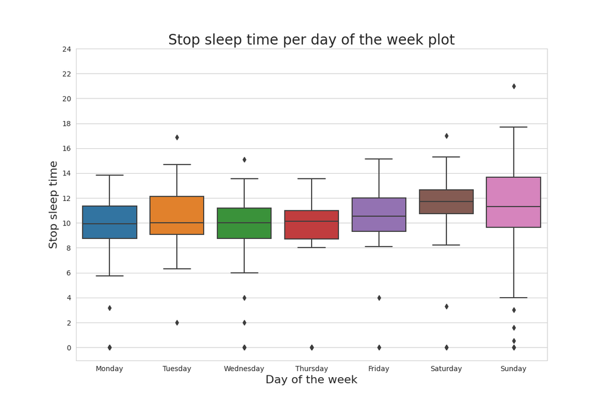

sleep_stop_time_per_month_boxplot.png

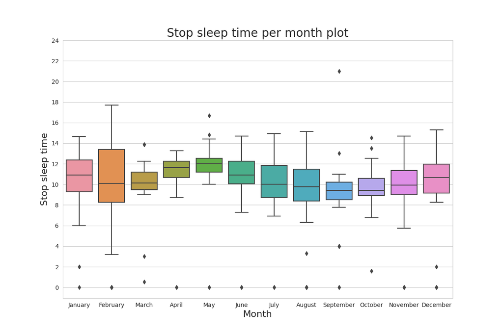

sleep_stop_time_per_year_boxplot.png

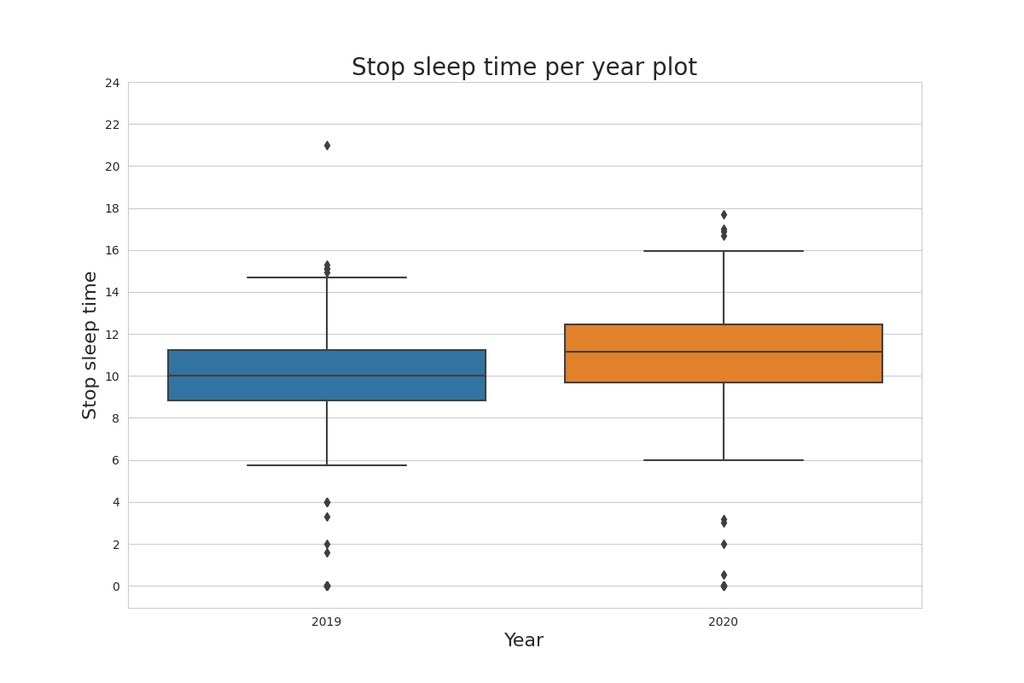

Here you can find your activity plots

Here you can find your common activity plots

activity_pairplot.png

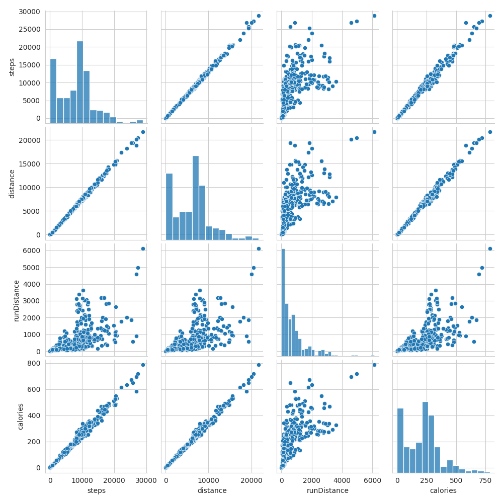

activity_boxplot.png

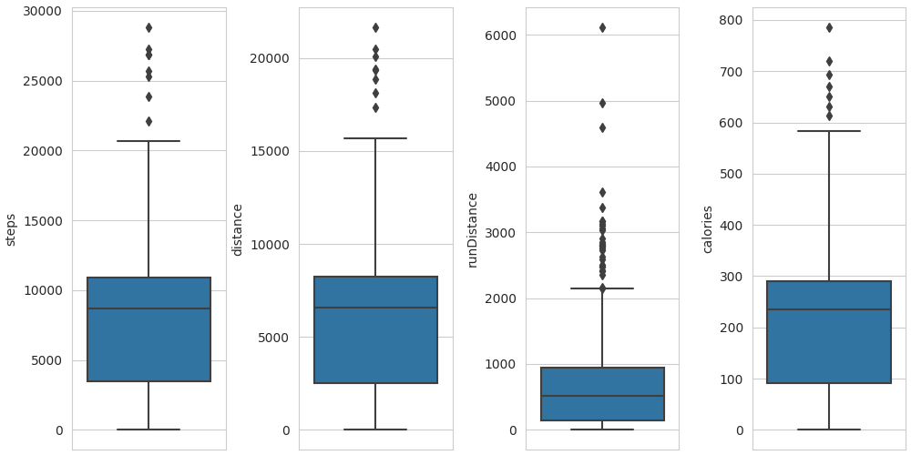

activity_steps_distance_scatterplot.png

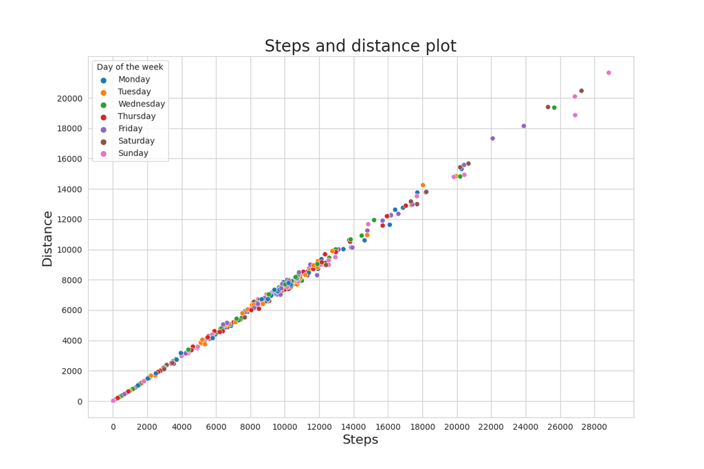

Here you can find your activity distance boxplots

activity_distance_per_weekday_boxplot.png

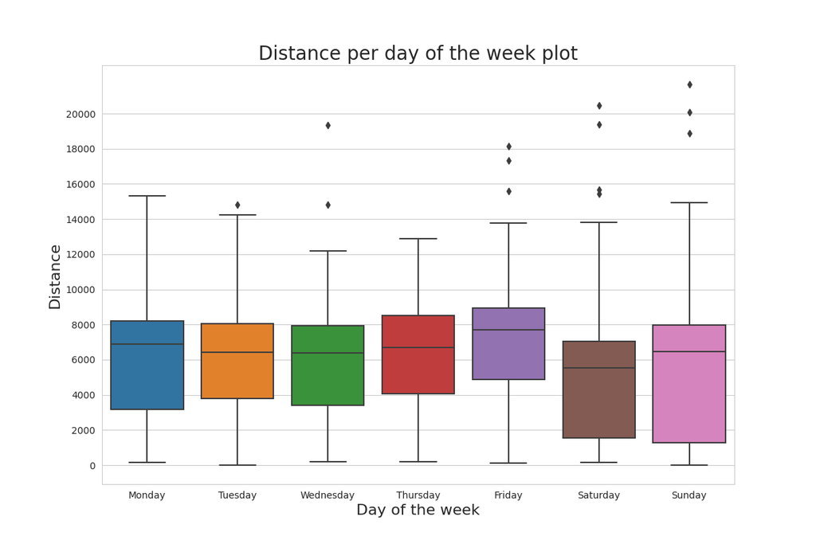

activity_distance_per_month_boxplot.png

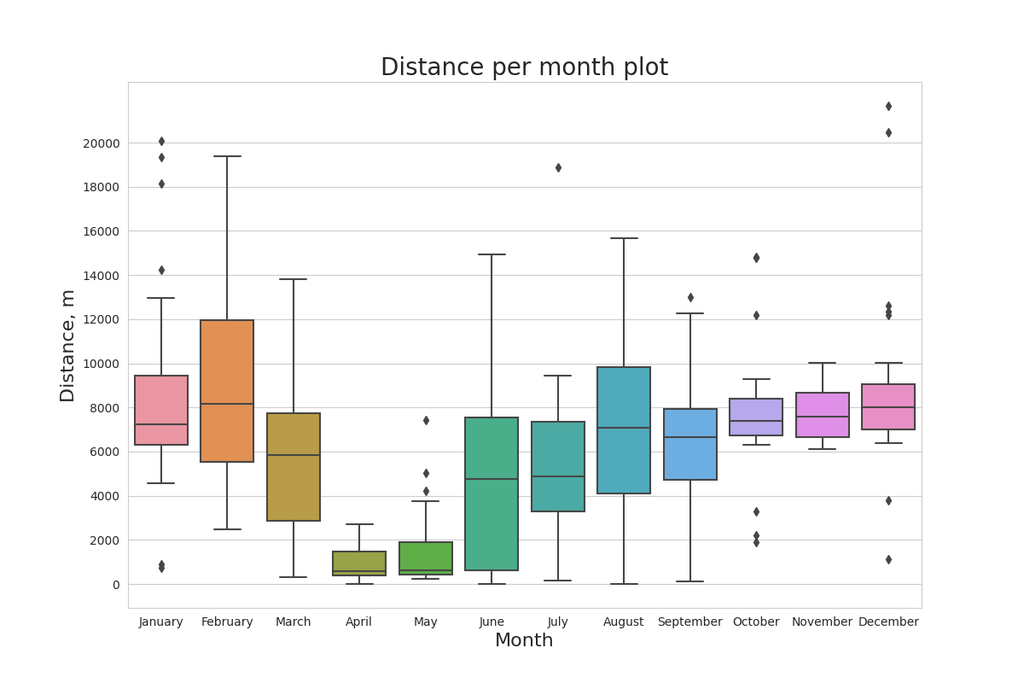

activity_distance_per_year_boxplot.png

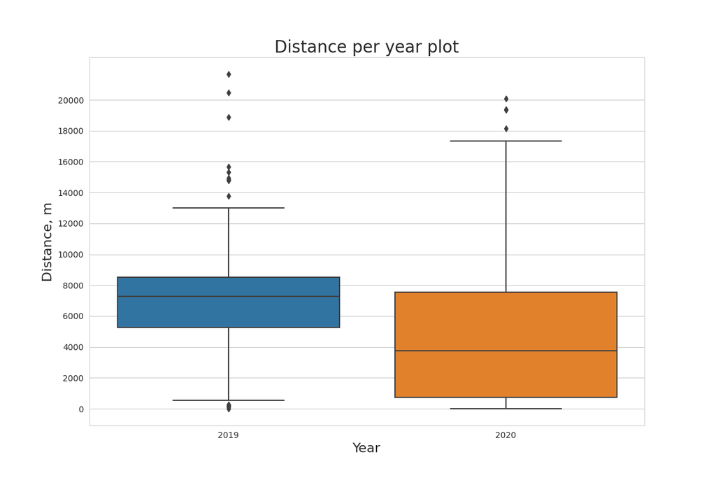

Here you can find your activity steps boxplots

activity_steps_per_weekday_boxplot.png

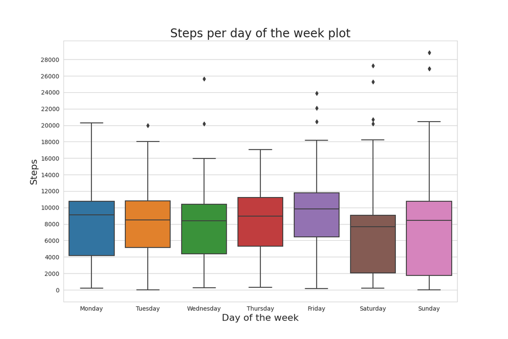

activity_steps_per_month_boxplot.png

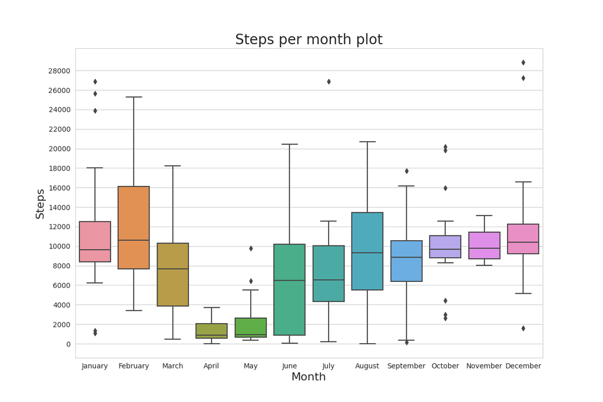

activity_steps_per_year_boxplot.png

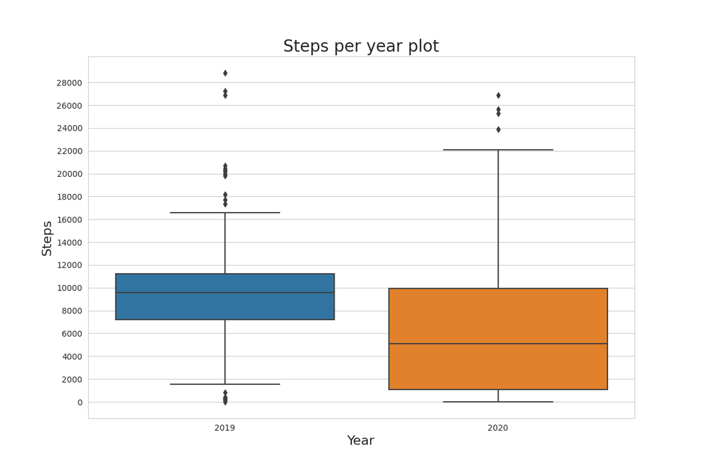

Here you can find your sleep activity plots

sleep_activity_correlations_plot.png

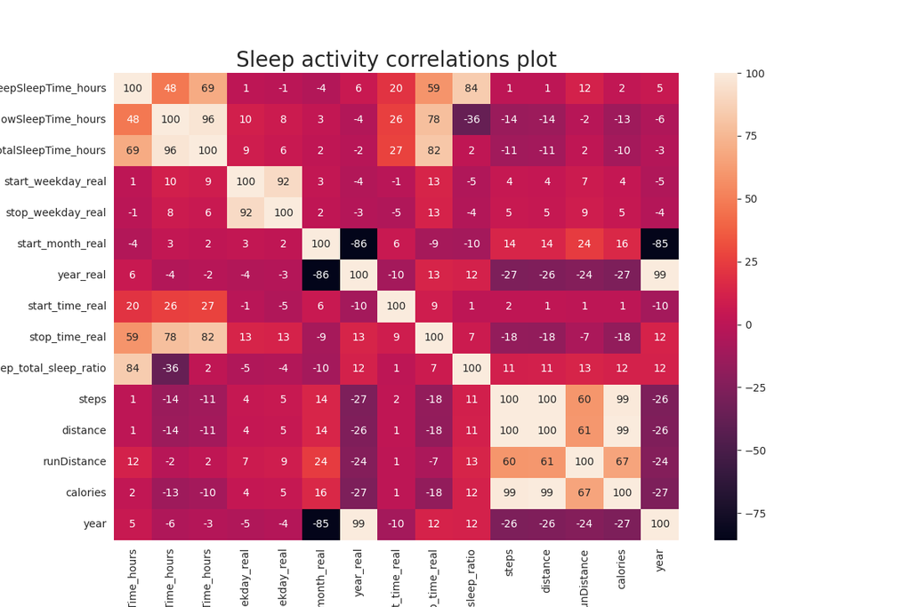

sleep_activity_steps_sleep_per_start_weekday_scatterplot.png

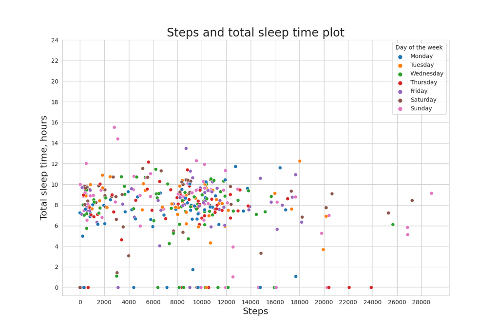

sleep_activity_steps_sleep_per_stop_weekday_scatterplot.png

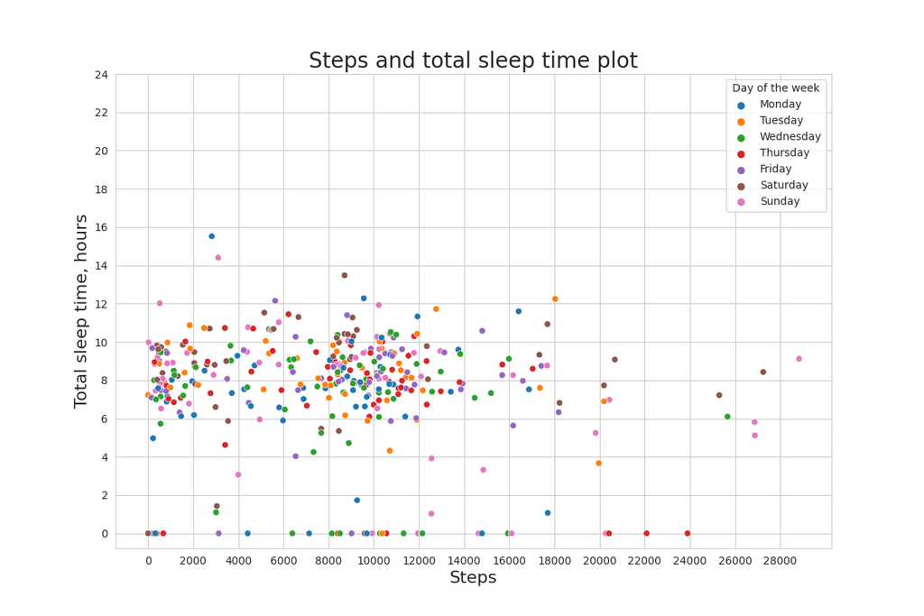

Here you can find your activity stage plots

activity_stage_histplot_km_h.png

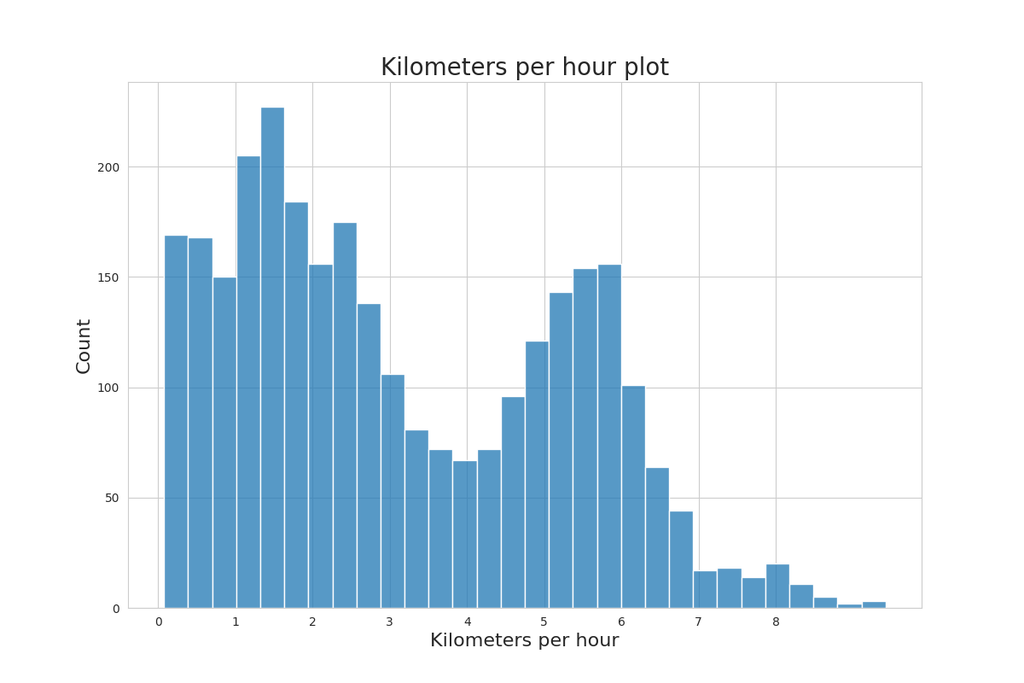

activity_stage_start_stop_hour_per_weekday_scatterplot.png

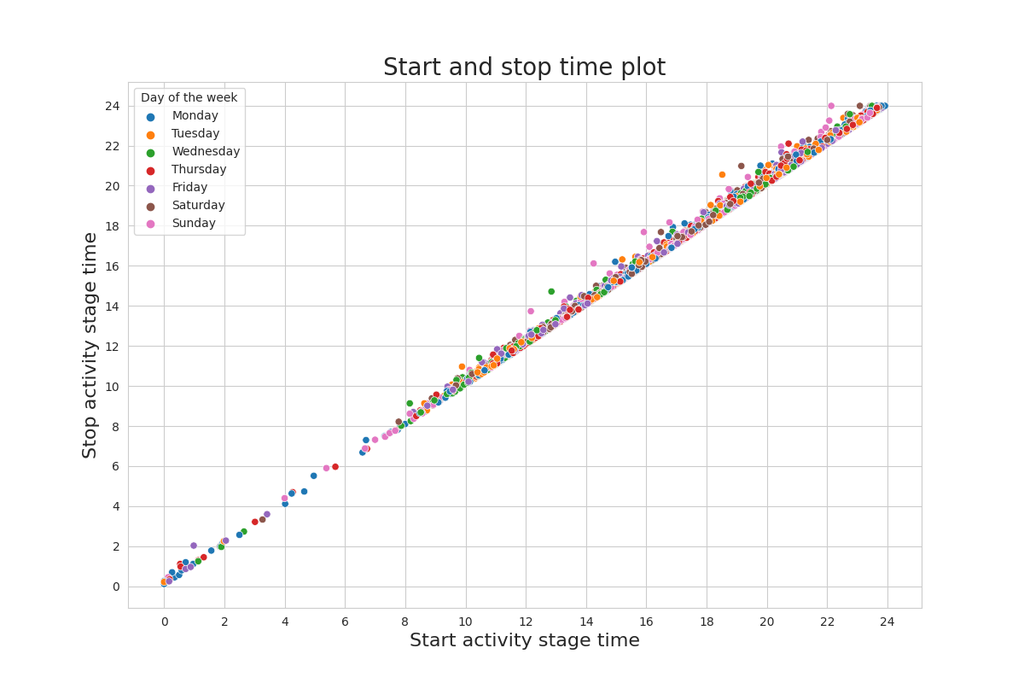

activity_stage_start_hour_and_steps_per_weekday_scatterplot.png

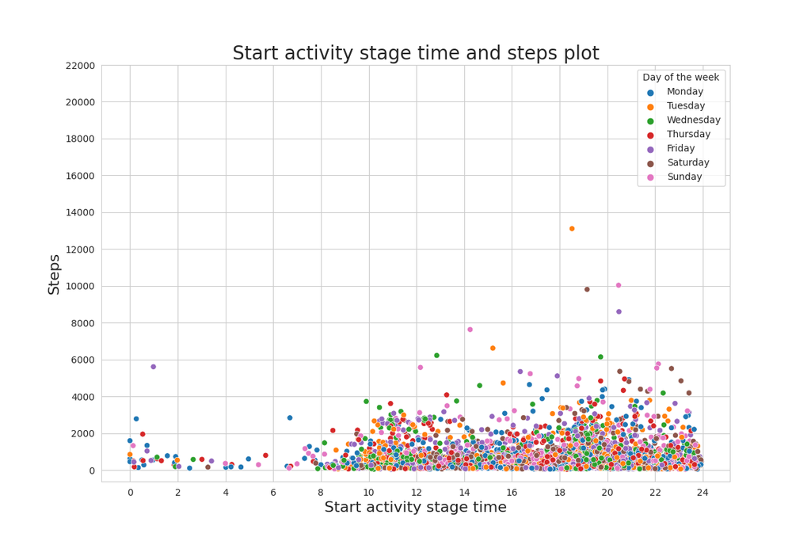